# HW1: A/B Testing and Simulating Key Ideas in Frequentist Statistical Inference

This notebook is written as a polished draft for the first blog post on a Quarto website. It uses simulation to explain several core ideas in classical frequentist inference in the setting of an A/B test.

## 1. Introduction

Suppose I am deciding between two versions of a homepage call-to-action button.

- **Version A:** "Start your free analysis"
- **Version B:** "See your data insights now"

The business question is simple: **does one version generate a higher click-through rate than the other?**

The statistical question is subtler. Even if one version performs better in my sample, I still have to decide whether the observed gap is large enough relative to sampling noise to count as meaningful evidence.

This is exactly the kind of setting where frequentist inference is useful. In this post, I use simulation and a simple A/B test to illustrate:

1. the Law of Large Numbers,
2. the Central Limit Theorem,
3. standard errors and confidence intervals,
4. hypothesis testing with a two-proportion z-test,
5. bootstrap uncertainty estimation, and
6. why "statistically significant" should not be the end of the conversation.

```python
import numpy as np
import pandas as pd
import matplotlib.pyplot as plt
from scipy.stats import norm

np.random.seed(495)
pd.set_option('display.float_format', lambda x: f"{x:,.4f}")
plt.rcParams['figure.figsize'] = (8, 5)
plt.rcParams['axes.spines.top'] = False
plt.rcParams['axes.spines.right'] = False
```

```
Matplotlib is building the font cache; this may take a moment.
```

## 2. Simulated A/B test setup

I begin with a stylized experiment. Assume the true click-through rates are:

- (p_A = 0.10)
- (p_B = 0.12)

So version B really is better, but only by **2 percentage points**. That is a realistic setting because many digital experiments involve modest effect sizes rather than dramatic wins.

```python
p_A = 0.10
p_B = 0.12
n_A = 4000
n_B = 4000

clicks_A = np.random.binomial(1, p_A, n_A)
clicks_B = np.random.binomial(1, p_B, n_B)

conv_A = clicks_A.mean()
conv_B = clicks_B.mean()
lift = conv_B - conv_A

summary = pd.DataFrame({
    'Group': ['A', 'B'],
    'Users': [n_A, n_B],
    'Clicks': [clicks_A.sum(), clicks_B.sum()],
    'Conversion Rate': [conv_A, conv_B]
})
summary
```

|  | Group | Users | Clicks | Conversion Rate |
| --- | --- | --- | --- | --- |
| 0 | A | 4000 | 406 | 0.1015 |
| 1 | B | 4000 | 477 | 0.1192 |

The observed difference in this particular sample is our first estimate of the treatment effect. But one sample is never the whole story. To understand why, it helps to simulate repeated sampling.

## 3. The Law of Large Numbers

For Bernoulli data, the sample mean is the sample conversion rate. The Law of Large Numbers says that as the sample size grows, the sample average converges toward the true probability.

I illustrate that below for version A, whose true conversion rate is 0.10.

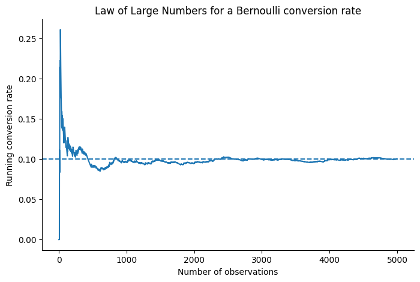

```python
true_p = p_A
n_max = 5000
sample = np.random.binomial(1, true_p, n_max)
running_mean = np.cumsum(sample) / np.arange(1, n_max + 1)

plt.figure()
plt.plot(running_mean)
plt.axhline(true_p, linestyle='--')
plt.xlabel('Number of observations')
plt.ylabel('Running conversion rate')
plt.title('Law of Large Numbers for a Bernoulli conversion rate')
plt.show()
```

Early in the sample path, the estimate jumps around a lot. As the number of observations increases, the running average stabilizes near the true rate. This is the logic behind why larger experiments give more precise estimates.

## 4. The Central Limit Theorem

The Central Limit Theorem says that for large samples, the sampling distribution of the sample mean is approximately normal, even when the underlying observations are binary.

To show this, I repeatedly simulate experiments of size (n=200) for version A and plot the resulting distribution of sample conversion rates.

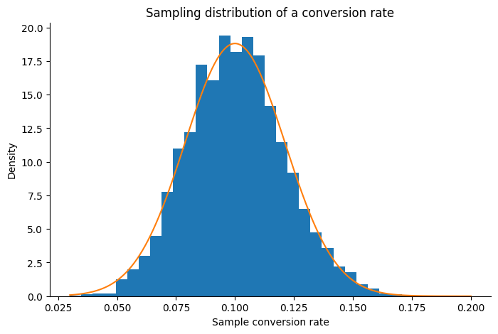

```python
reps = 5000
n = 200
sample_means = np.random.binomial(1, p_A, size=(reps, n)).mean(axis=1)

mu = p_A
se = np.sqrt(p_A * (1 - p_A) / n)
x = np.linspace(sample_means.min(), sample_means.max(), 300)

plt.figure()
plt.hist(sample_means, bins=35, density=True)
plt.plot(x, norm.pdf(x, mu, se))
plt.xlabel('Sample conversion rate')
plt.ylabel('Density')
plt.title('Sampling distribution of a conversion rate')
plt.show()
```

Even though each individual observation is just 0 or 1, the sample mean has a smooth bell-shaped sampling distribution. This is what makes z-tests and normal-approximation confidence intervals practical in A/B testing.

## 5. Estimating uncertainty with standard errors

```python
se_A = np.sqrt(conv_A * (1 - conv_A) / n_A)
se_B = np.sqrt(conv_B * (1 - conv_B) / n_B)
se_diff = np.sqrt(conv_A * (1 - conv_A) / n_A + conv_B * (1 - conv_B) / n_B)

ci_low = lift - 1.96 * se_diff
ci_high = lift + 1.96 * se_diff

uncertainty = pd.DataFrame({
    'Metric': ['Conversion rate A', 'Conversion rate B', 'Difference (B - A)'],
    'Estimate': [conv_A, conv_B, lift],
    'Standard Error': [se_A, se_B, se_diff],
    '95% CI Lower': [conv_A - 1.96*se_A, conv_B - 1.96*se_B, ci_low],
    '95% CI Upper': [conv_A + 1.96*se_A, conv_B + 1.96*se_B, ci_high],
})
uncertainty
```

|  | Metric | Estimate | Standard Error | 95% CI Lower | 95% CI Upper |
| --- | --- | --- | --- | --- | --- |
| 0 | Conversion rate A | 0.1015 | 0.0048 | 0.0921 | 0.1109 |
| 1 | Conversion rate B | 0.1192 | 0.0051 | 0.1092 | 0.1293 |
| 2 | Difference (B - A) | 0.0177 | 0.0070 | 0.0040 | 0.0315 |

The confidence interval for the treatment effect is especially important because it communicates both **direction** and **magnitude**. A p-value alone cannot do that.

## 6. A formal hypothesis test

I now test the null hypothesis that the two versions have equal conversion rates:

[ H_0: p_A = p_B ]

For the classical two-proportion z-test, the null standard error is based on the **pooled** conversion rate.

```python
click_count_A = clicks_A.sum()
click_count_B = clicks_B.sum()
pooled = (click_count_A + click_count_B) / (n_A + n_B)
se_null = np.sqrt(pooled * (1 - pooled) * (1/n_A + 1/n_B))
z = (conv_B - conv_A) / se_null
p_value = 2 * (1 - norm.cdf(abs(z)))

hyp_test = pd.DataFrame({
    'Statistic': ['Observed difference', 'Pooled rate', 'Null SE', 'z statistic', 'p-value'],
    'Value': [lift, pooled, se_null, z, p_value]
})
hyp_test
```

|  | Statistic | Value |
| --- | --- | --- |
| 0 | Observed difference | 0.0177 |
| 1 | Pooled rate | 0.1104 |
| 2 | Null SE | 0.0070 |
| 3 | z statistic | 2.5332 |
| 4 | p-value | 0.0113 |

If the p-value is small, the sample would be considered unlikely under the null hypothesis of no difference. In that case, the frequentist conclusion is that the data provide evidence against (H_0).

Still, it is important to state clearly what the p-value does **not** mean. It is **not** the probability that the null hypothesis is true. It is the probability of seeing data at least this extreme **if the null were true**.

## 7. Visualizing effect size and uncertainty

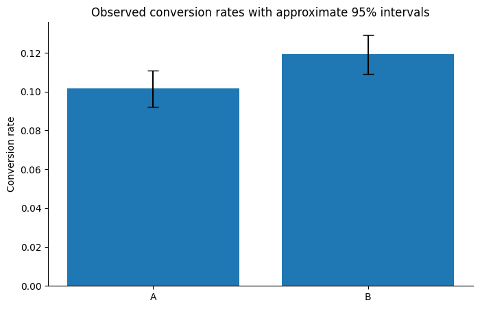

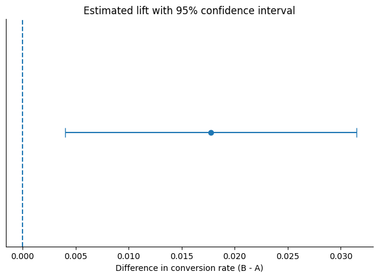

```python
plt.figure()
plt.bar(['A', 'B'], [conv_A, conv_B], yerr=[1.96*se_A, 1.96*se_B], capsize=6)
plt.ylabel('Conversion rate')
plt.title('Observed conversion rates with approximate 95% intervals')
plt.show()

plt.figure()
plt.errorbar([lift], [0], xerr=[1.96 * se_diff], fmt='o', capsize=6)
plt.axvline(0, linestyle='--')
plt.yticks([])
plt.xlabel('Difference in conversion rate (B - A)')
plt.title('Estimated lift with 95% confidence interval')
plt.show()
```

These graphics make the main result easier to interpret. They show not only that version B appears better, but also the range of treatment effects compatible with the data.

## 8. Bootstrap check

The bootstrap approximates the sampling distribution by resampling from the observed data. It is especially useful when an analytic standard error is hard to derive.

For a simple difference in proportions, the analytic approach is already available, but the bootstrap is still a good diagnostic and a useful teaching device.

```python
B = 4000
boot_diffs = np.empty(B)
for b in range(B):
    boot_A = np.random.choice(clicks_A, size=n_A, replace=True)
    boot_B = np.random.choice(clicks_B, size=n_B, replace=True)
    boot_diffs[b] = boot_B.mean() - boot_A.mean()

boot_se = boot_diffs.std(ddof=1)
boot_ci = np.quantile(boot_diffs, [0.025, 0.975])

bootstrap_table = pd.DataFrame({
    'Method': ['Analytic', 'Bootstrap'],
    'SE of lift': [se_diff, boot_se],
    '95% CI lower': [ci_low, boot_ci[0]],
    '95% CI upper': [ci_high, boot_ci[1]],
})
bootstrap_table
```

|  | Method | SE of lift | 95% CI lower | 95% CI upper |
| --- | --- | --- | --- | --- |
| 0 | Analytic | 0.0070 | 0.0040 | 0.0315 |
| 1 | Bootstrap | 0.0070 | 0.0045 | 0.0318 |

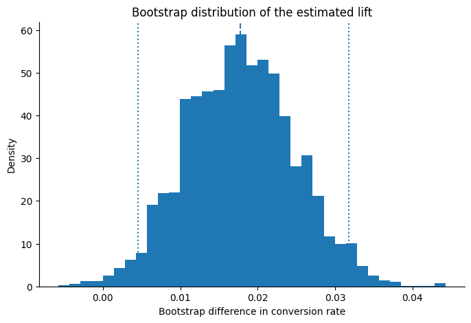

```python
plt.figure()
plt.hist(boot_diffs, bins=35, density=True)
plt.axvline(lift, linestyle='--')
plt.axvline(boot_ci[0], linestyle=':')
plt.axvline(boot_ci[1], linestyle=':')
plt.xlabel('Bootstrap difference in conversion rate')
plt.ylabel('Density')
plt.title('Bootstrap distribution of the estimated lift')
plt.show()
```

The bootstrap result should usually be close to the analytic result here. That agreement is reassuring: two different routes to uncertainty quantification lead to a similar answer.

## 9. Why statistical significance is not enough

A common mistake in A/B testing is to reduce the result to a binary label such as “significant” or “not significant.” That is too crude for decision-making.

Three issues matter in practice:

### 9.1 Effect size

A result can be statistically significant but economically trivial. With enough traffic, even a tiny lift can produce a very small p-value.

### 9.2 Precision

Confidence intervals help answer a more useful question: **how large might the true effect reasonably be?**

### 9.3 Context

A homepage CTA test is not judged in a vacuum. The team should also consider implementation cost, user experience, brand voice, and downstream outcomes such as retention or purchases.

## 10. Small effect, huge sample: a cautionary simulation

```python
np.random.seed(496)
small_p_A = 0.100
small_p_B = 0.102
big_n = 100_000

big_A = np.random.binomial(1, small_p_A, big_n)
big_B = np.random.binomial(1, small_p_B, big_n)

phat_A = big_A.mean()
phat_B = big_B.mean()
small_lift = phat_B - phat_A
pooled_big = (big_A.sum() + big_B.sum()) / (2 * big_n)
se_big = np.sqrt(pooled_big * (1 - pooled_big) * (2 / big_n))
z_big = small_lift / se_big
p_big = 2 * (1 - norm.cdf(abs(z_big)))

pd.DataFrame({
    'Quantity': ['Estimated rate A', 'Estimated rate B', 'Estimated lift', 'z statistic', 'p-value'],
    'Value': [phat_A, phat_B, small_lift, z_big, p_big]
})
```

|  | Quantity | Value |
| --- | --- | --- |
| 0 | Estimated rate A | 0.1006 |
| 1 | Estimated rate B | 0.1015 |
| 2 | Estimated lift | 0.0009 |
| 3 | z statistic | 0.6381 |
| 4 | p-value | 0.5234 |

## 11. Conclusion

This A/B testing example illustrates several pillars of frequentist statistical inference.

- The **Law of Large Numbers** explains why sample averages stabilize.
- The **Central Limit Theorem** explains why sample proportions can often be analyzed with normal approximations.
- **Standard errors** and **confidence intervals** quantify uncertainty.
- A **hypothesis test** evaluates whether the data are inconsistent with a null of no treatment effect.
- The **bootstrap** provides a simulation-based way to estimate uncertainty.
- Most importantly, **good reporting goes beyond a binary significant/not significant label**.

For this simulated experiment, version B appears to outperform version A. But the larger lesson is methodological: a sound A/B test analysis should report effect sizes, uncertainty, and practical implications together.

## 12. Optional next step for Quarto blog conversion

If you want to post this on your Quarto website, the easiest workflow is:

1. open this notebook in Jupyter or VS Code,
2. confirm the outputs and edit the prose to sound like you,
3. either render it directly in Quarto or copy the code and markdown into a `.qmd` blog post,
4. place the post under `posts/ab-testing-frequentist/`, and
5. re-render and publish your website.